# PRACTICUM IN DATA ANALYSIS – Data visualization

#### Overview

This visulation can be divided into four parts: the relationship between timely response rate and narratives length; the word usage in narratives; timely response rate according to product; the complaints distribution for EQUIFAX, INC.

```r
library(readr)
library(dplyr)
library(tm)
```

```r
library(tidytext)
library(wordcloud)
library(RXKCD)
library(RColorBrewer)
```

```r
library(ggplot2)
library(stringr)
library(maps)
library(maptools)
library(mapproj)
```

```r
d <- read.csv('D:complaints.csv')
```

```r
#subset data to those having narratives
data <- d[d$Consumer.complaint.narrative != '', ]
```

```r
library(caret)
```

#### 1. The relationship between timely response rate and narratives length

In this section, I use subset of dataset to investigate whether the length of complaint affects the chance of timely response.  
According to below plot, my preliminary conclusion is that the length of complaint narratives would not significant affect the probability of being timely responsed.

```r
sampling <- createDataPartition(y = data$Product, p = 0.025, list = FALSE)
sample <- data[sampling, ]
```

```r
myCorpus <- Corpus(VectorSource(as.character(sample$Consumer.complaint.narrative)))
```

```r
#remove stopwords and meaningless xs
cleancor <- tm_map(myCorpus, removeWords, stopwords("english"))
cleancor <- tm_map(cleancor, removeWords, c('xxxx', 'xxxxxxxx'))
cleantext <- data.frame(text = sapply(cleancor, as.character), stringsAsFactors = FALSE)
```

```r
len_s <- sapply(gregexpr("\\S+", cleantext$text), length)
```

```r
sample$len_s <- len_s
s3 <- sample %>%　group_by(len_s) %>%
  summarize(y = sum(Timely.response.=="Yes"), n = sum(Timely.response.=="No"))
```

```r
# Calculate timey response rate for each narrative length
s3$pro <- s3$n/(s3$y + s3$n)
```

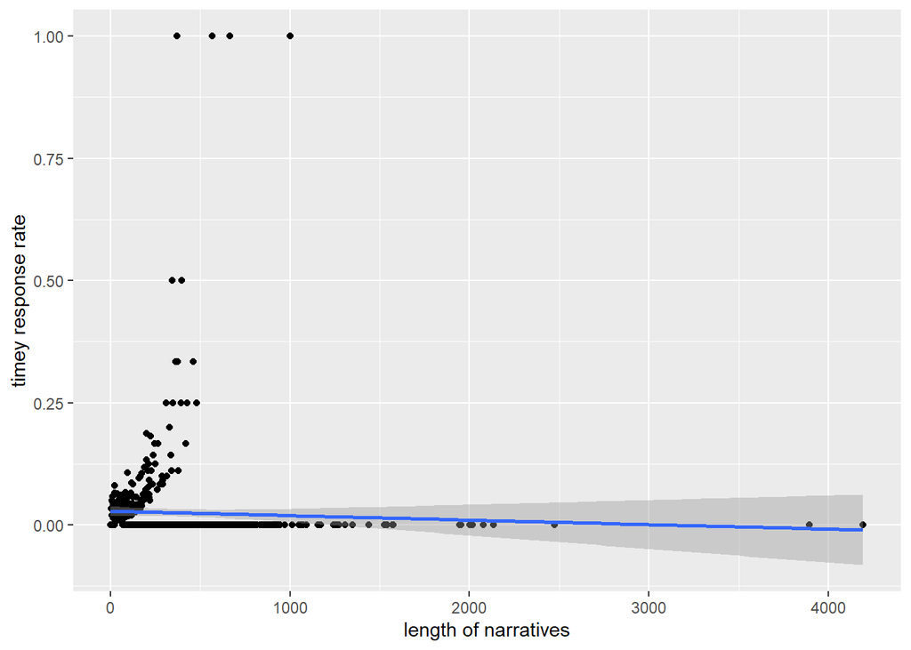

```r
ggplot(s3) +
  geom_point(aes(x = len_s, y = pro)) +
  geom_smooth(aes(x = len_s, y = pro), method = "lm") +
  labs(y = "timey response rate", x = "length of narratives")
```

#### 2. The word usage in narratives

In this section, I use wordclud to explore whether those complaints that get timely response use different word from those ignored complaints. My first plot show the word usage for timely responsed complaints and the second show the word usage for neglected complaints. The results show that the word ‘credit’ outstands in the ignored complaints but not timely responsed complaints. This may suggests that issues about credit service tend to need more time to process.

```r
#split sample into two group according to timely response variable
sample_have <- sample %>% filter(Timely.response. == 'Yes')
sample_no <- sample %>% filter(Timely.response. == 'No')
```

```r
corpushave <- Corpus(VectorSource(as.character(sample_have$Consumer.complaint.narrative)))
```

```r
corpushave <- tm_map(corpushave, content_transformer(tolower))
corpushave <- tm_map(corpushave, stripWhitespace)
corpushave <- tm_map(corpushave, removePunctuation)
corpushave <- tm_map(corpushave, removeNumbers)
corpushave <- tm_map(corpushave, removeWords, stopwords("english"))
corpushave <- tm_map(corpushave, removeWords, c('xxxx', 'xxxxxxxx'))
tdmhave <- TermDocumentMatrix(corpushave)
mhave <- as.matrix(tdmhave)
vhave <- sort(rowSums(mhave),decreasing=TRUE)
dhave <- data.frame(word = names(vhave),freq=vhave)
```

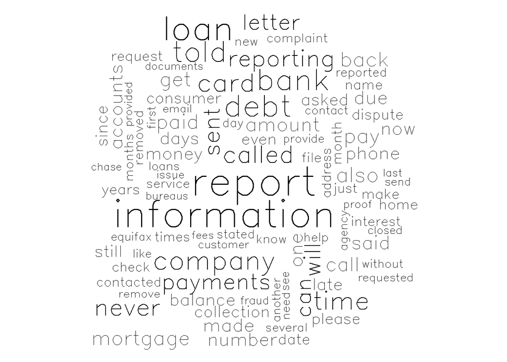

```r
wordcloud(dhave$word, dhave$freq, scale=c(8,.3),min.freq=10,max.words=100, random.order=T, rot.per=.15,  vfont=c("sans serif","plain"))
```

```r
corpusno <- Corpus(VectorSource(as.character(sample_no$Consumer.complaint.narrative)))
```

```r
corpusno <- tm_map(corpusno, content_transformer(tolower))
corpusno <- tm_map(corpusno, stripWhitespace)
corpusno <- tm_map(corpusno, removePunctuation)
corpusno <- tm_map(corpusno, removeNumbers)
corpusno <- tm_map(corpusno, removeWords, stopwords("english"))
corpusno <- tm_map(corpusno, removeWords, c('xxxx', 'xxxxxxxx'))
tdmno <- TermDocumentMatrix(corpusno)
mno <- as.matrix(tdmno)
vno <- sort(rowSums(mno),decreasing=TRUE)
dno <- data.frame(word = names(vno),freq=vno)
```

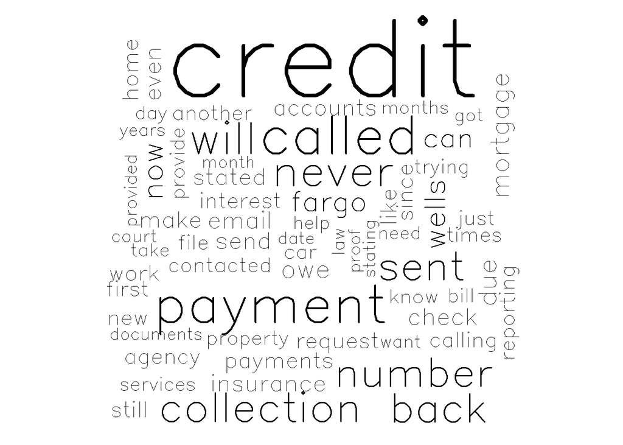

```r
set.seed(3921)
wordcloud(dno$word, dno$freq, scale=c(8,.3),min.freq=1,max.words=100, random.order=T, rot.per=.15, vfont=c("sans serif","plain"))
```